# Mathematical Foundations of Data Science Assignment 1

## Trimester 2, 2024

## Question 1

- The statement in set notation means for any y belongs to rational numbers, there is an absolute value of y smaller than y.
- The statement is false. For example there is a positive number like 5 belongs to rational numbers but its absolute value is 5 itself which equals 5 but not smaller.

## Question 2

- (a) The domain of *g* is $(-1,5)$.
- (b) It is. As the graph shows the function has 2 dots at 3 but only the upper dot is solid which means the value of g when $x=3$ is 4.
- (c) The expression of *g* on domain $[1,5)$ is $$f = \begin{cases} \frac12(x-1)^2+2,&x\in[1,3]\\ -\frac12x+\frac72,&x\in(3,5) \end{cases}$$
  Then we channge the places of $x$ and $f$, then we can plot the graph of $f^{-1}$ in Jupyterbook:

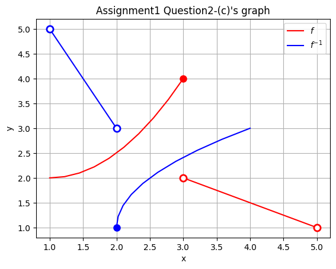

```python
import numpy as np
import matplotlib.pyplot as plt

# Define the piecewise function
x1 = np.linspace(1, 3, 10)  # The domian of the first part of this function
x2 = np.linspace(3, 5, 10)  # The domian of the second part of this function
y1 = 0.5 * (x1 - 1) ** 2 + 2  # The first part's expression
y2 = -0.5 * x2  + 3.5  # The second part's expression

# Plot the curve of the piecewise function
plt.plot(x1, y1, 'r',label='$f$')  # Plot the first part
plt.plot(x2, y2, 'r')  # Plot the second part
plt.plot(x1[-1], y1[-1], 'o', markersize=8, markerfacecolor='r',color = 'r') #The solid point of the first part at x=3
plt.plot(x2[0], y2[0], 'o',markersize=8, markerfacecolor='white', markeredgewidth=2, color = 'r') # The hollow point of the second part at x=3
plt.plot(x2[-1], y2[-1], 'o', markersize=8, markerfacecolor='white', markeredgewidth=2, color = 'r') # The hollow point of the second part at x=5

# Plot the curve of its inverse function
plt.plot(y1,x1,'b',label='$f^{-1}$') # Swap x1 and y1 to plot the first part of the inverse function
plt.plot(y2,x2,'b') # Swap x2 and y2 to plot the first part of the inverse function
plt.plot(y1[0],x1[0],'o',markersize=8, markerfacecolor = 'b',color = 'b')#The solid point of the first part at x=3 whic means y=2
plt.plot(y2[0],x2[0],'o',markersize=8, markerfacecolor='white',markeredgewidth=2,color = 'b') # The hollow point of the second part at x=3 whic means y=2
plt.plot(y2[-1],x2[-1],'o',markersize=8, markerfacecolor='white',markeredgewidth=2,color = 'b') # The hollow point of the second part at x=5 whic means y =1

# Set the legend and grid
plt.legend()
plt.grid()

# Set the title and labels
plt.title("Assignment1 Question2-(c)'s graph")
plt.xlabel('x')
plt.ylabel('y')

# Show the graph
plt.show()
```

## Question 3

- (a) $A\backslash \Z=\{\frac{1}{4},\frac{3}{2},\pi\} $
- (b) $A\cap B=\{0,\frac{1}{4},\frac{3}{2}\}$

## Question 4

- To find $h^{-1}(x)$, we just switch all instances of $x$ and $h(x)$, which is

$$ x=\frac{h^{-1}(x)+3}{2}\\ ~\\ h^{-1}(x)=2x-3 $$

- The domain of $h(x)$ is $[1,+\infty)$, which indicates the range of $h(x)$ is $[2,+\infty)$. As the concept of inverse functions we can learn the domain of $h^{-1}(x)$ is the ranger of $h(x)$, which is $[2,+\infty)$.

## Question 5

- (a) We should import pandas first then creat a variable `df1` and assign the reading of csv to it. Then we use `head()` to print it out.

```python
import pandas as pd

df1 = pd.read_csv('swimming.csv')
df1.head()
```

|  | Rank | Type | Number | Lane | Swimmer | Nation | Time |
| --- | --- | --- | --- | --- | --- | --- | --- |
| 0 | 48 | Heat | 4 | 1 | Matthew Abeysinghe | Sri Lanka | 50.62 |
| 1 | 53 | Heat | 3 | 1 | Issa Al-Adawi | Oman | 51.81 |
| 2 | 8 | Heat | 9 | 6 | David Popovici | Romania | 48.03 |
| 3 | 50 | Heat | 3 | 6 | Yousuf Al-Matrooshi | United Arab Emirates | 51.50 |
| 4 | 18 | Heat | 7 | 1 | Apostolos Christou | Greece | 48.50 |

- (b) We could import `matplotlib` first, then we creat a filter with only times in `df1`. Then we use `plt.hist` to create the histogram of all Times divided into different intervals. Finally we use `plt.xlabel`, `plt.ylabel`, `plt.legend` and `plt.title` to add details.

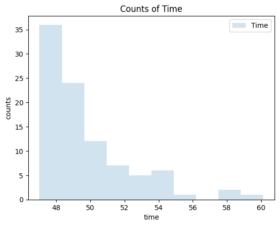

```python
import matplotlib.pyplot as plt

time = df1['Time']
plt.hist(time,label='Time',alpha = 0.2)
plt.xlabel('time')
plt.ylabel('counts')
plt.legend()
plt.title('Counts of Time')
```

- (c) The mean time is `49.805`. We dould use `.mean()` to calculate it.

```python
m_time = round(df1['Time'].mean(),3)
print(m_time)
```

```
49.805
```

- (d) We could use the code below to find who is the fasteset one in the heats, it's `Thomas Ceccon`.

```python
df2 = df1[df1['Type'] == 'Heat']
df2[df2['Rank'] == 1]
```

|  | Rank | Type | Number | Lane | Swimmer | Nation | Time |
| --- | --- | --- | --- | --- | --- | --- | --- |
| 92 | 1 | Heat | 9 | 2 | Thomas Ceccon | Italy | 47.71 |

- (e) To find who is the slowest, we could use the code below. It's `Roman Mityukov`

```python
df3 = df1[df1['Type'] == 'Semifinal']
df_semi2 = df3[df3['Number'] == 2]
df_semi2[df_semi2['Time'] == df_semi2.max()['Time']]
```

|  | Rank | Type | Number | Lane | Swimmer | Nation | Time |
| --- | --- | --- | --- | --- | --- | --- | --- |
| 7 | 16 | Semifinal | 2 | 8 | Roman Mityukov | Switzerland | 48.53 |